# Previziunea anulării rezervării unei camere de hotel

Țânțarcu Alexandra-Andreea & Țepurică Ana-Maria, Grupa 1118

Published

January 28, 2023

## Motivația temei

- **Care e problema pe care o rezolvăm?**

Cu această aplicatie încercăm să realizăm o previziune pentru a observa cauzele anulării unei rezervări la hotel, astfel încât să îmbunătățim serviciile oferite pentru a reduce numărul anulărilor și, totodată, să putem anticipa dacă o rezervare va fi sau nu anulată. Previziunea va fi facută pentru a vedea dependența între posibilitatea ca o rezervare să fie anulată, booking_status și variabilele numerice prezente în setul nostru.

- **De ce este importantă problema, de ce este interesantă? De ce e importantă pentru firmă? De ce e importantă pentru noi?**

Modalitățile de rezervare online la hotel au schimbat dramatic posibilitățile și comportamentul clienților. Un număr semnificativ de rezervări la hotel sunt anulate din cauza anulării fără motiv sau a neprezentării. Motivele tipice pentru anulări includ schimbarea planurilor, intervin alte probleme mai importante ale clienților etc. Acest lucru este adesea facilitat de opțiunea de a face acest lucru gratuit sau, de preferință, la un cost scăzut, care este benefic pentru oaspeții hotelului, dar este un venit mai puțin dezirabil și posibil – fiind un factor descrescător cu care să se ocupe hotelurile.

- **Cum am curățat/preprocesat datele?**

Verificarea setului de date în privința valorilor lipsă, pentru a obține o analiză relevantă, setul de date inițial a fost împărțit în set de antrenare si set de testare (70%-30%, 75%-25%), standardizarea seturilor de antrenare înainte de aplicarea metodelor.

### Descrierea datelor

Setul de date conține 36275 observații despre clienții și rezervările efectuate de aceștia într-un hotel și 19 variabile. Variabilele se referă la detaliile rezervării, acestea fiind următoarele:

- Booking_ID: ID unic pentru fiecare rezervare
- no_of_adults: Numărul de adulți
- no_of_children: Numărul de copii
- no_of_weekend_nights: Numărul nopților de weekend rezervate (Sâmbătă sau Duminică)
- no_of_week_nights: Numărul nopților din timpul săptămânii rezervate (Luni-Vineri)
- type_of_meal_plan: Tipul de pachet pentru serviciul de luat masa
- required_car_parking_space: Necesitatea unui loc de parcare (0 - No, 1- Yes)
- room_type_reserved: Tipul de cameră rezervată

*Analiza este realizată pentru tipurile de camere evaluate de INN Hotels, nefiind specificat exact tipul camerei (de ex. Tip 1 = apartament, Tip 2 = studio etc).*

- lead_time: Numărul rămas de zile până la check-in
- arrival_year: Anul rezervării
- arrival_month: Luna rezervării
- arrival_date: Ziua rezervării
- market_segment_type: Market segment designation.
- repeated_guest: Client vechi (0 - No, 1- Yes)
- no_of_previous_cancellations: Numărul de anulări anterioare
- no_of_previous_bookings_not_canceled: Numărul de rezervări neanulate
- avg_price_per_room: Prețul mediu al unei camere, prețurile sunt dinamice (în euro)
- no_of_special_requests: Numărul total de cerințe speciale (ex. Vedere către munte/mare etc.)
- booking_status: Status rezervare (0 – Canceled, 1- Not_Canceled) Am modificat in Excel tipul de status folosind functia if() dupa cum am specificat mai sus.

### Încărcarea seturilor de date

```r
date = read.csv("date.csv",header=TRUE, sep=",")
date1 = read.csv("date1.csv",header=TRUE, sep=",")
cor = read.csv("cor.csv",header=TRUE, sep=",")
datei = read.csv("datei.csv",header=TRUE, sep=",")
summary = read.csv("summary.csv",header=TRUE, sep=",")
```

**Transformarea coloanei booking_status**

```r
#install.packages("dplyr")
library(dplyr)
date2 <- date %>%
mutate( booking_status = if_else(booking_status == 1, "Not_Canceled", "Canceled") )  %>%
mutate_if(is.character, as.factor) %>%
dplyr::select(booking_status)
head(date2,10)
```

```
   booking_status
1    Not_Canceled
2    Not_Canceled
3        Canceled
4        Canceled
5        Canceled
6        Canceled
7    Not_Canceled
8    Not_Canceled
9    Not_Canceled
10   Not_Canceled
```

### Verificarea valorilor lipsa în setul de date inițial

```r
sapply(datei, function(x) sum(is.na(x)))
```

```
                          Booking_ID                         no_of_adults
                                   0                                    0
                      no_of_children                 no_of_weekend_nights
                                   0                                    0
                   no_of_week_nights                    type_of_meal_plan
                                   0                                    0
          required_car_parking_space                   room_type_reserved
                                   0                                    0
                           lead_time                         arrival_year
                                   0                                    0
                       arrival_month                         arrival_date
                                   0                                    0
                 market_segment_type                       repeated_guest
                                   0                                    0
        no_of_previous_cancellations no_of_previous_bookings_not_canceled
                                   0                                    0
                  avg_price_per_room               no_of_special_requests
                                   0                                    0
                      booking_status
                                   0
```

După cum putem observa, nu avem valori lipsă în setul de date.

### Matricea de corelație

```r
matrice_corelatieD<- cor(cor)
matrice_corelatieD
```

```
                                     no_of_adults no_of_children
no_of_adults                           1.00000000    -0.01978707
no_of_children                        -0.01978707     1.00000000
no_of_weekend_nights                   0.10331578     0.02947758
no_of_week_nights                      0.10562190     0.02439811
no_of_previous_cancellations          -0.04742575    -0.01638958
no_of_previous_bookings_not_canceled  -0.11916579    -0.02118896
avg_price_per_room                     0.29688574     0.33772791
no_of_special_requests                 0.18940095     0.12448619
booking_status                        -0.08692030    -0.03307782
                                     no_of_weekend_nights no_of_week_nights
no_of_adults                                   0.10331578        0.10562190
no_of_children                                 0.02947758        0.02439811
no_of_weekend_nights                           1.00000000        0.17957676
no_of_week_nights                              0.17957676        1.00000000
no_of_previous_cancellations                  -0.02069048       -0.03008040
no_of_previous_bookings_not_canceled          -0.02631198       -0.04934374
avg_price_per_room                            -0.00452459        0.02275269
no_of_special_requests                         0.06059253        0.04599365
booking_status                                -0.06156254       -0.09299601
                                     no_of_previous_cancellations
no_of_adults                                         -0.047425747
no_of_children                                       -0.016389584
no_of_weekend_nights                                 -0.020690482
no_of_week_nights                                    -0.030080402
no_of_previous_cancellations                          1.000000000
no_of_previous_bookings_not_canceled                  0.468146833
avg_price_per_room                                   -0.063340386
no_of_special_requests                               -0.003317358
booking_status                                        0.033727803
                                     no_of_previous_bookings_not_canceled
no_of_adults                                                  -0.11916579
no_of_children                                                -0.02118896
no_of_weekend_nights                                          -0.02631198
no_of_week_nights                                             -0.04934374
no_of_previous_cancellations                                   0.46814683
no_of_previous_bookings_not_canceled                           1.00000000
avg_price_per_room                                            -0.11368386
no_of_special_requests                                         0.02737658
booking_status                                                 0.06017942
                                     avg_price_per_room no_of_special_requests
no_of_adults                                 0.29688574            0.189400951
no_of_children                               0.33772791            0.124486186
no_of_weekend_nights                        -0.00452459            0.060592526
no_of_week_nights                            0.02275269            0.045993653
no_of_previous_cancellations                -0.06334039           -0.003317358
no_of_previous_bookings_not_canceled        -0.11368386            0.027376578
avg_price_per_room                           1.00000000            0.184380955
no_of_special_requests                       0.18438096            1.000000000
booking_status                              -0.14256934            0.253069805
                                     booking_status
no_of_adults                            -0.08692030
no_of_children                          -0.03307782
no_of_weekend_nights                    -0.06156254
no_of_week_nights                       -0.09299601
no_of_previous_cancellations             0.03372780
no_of_previous_bookings_not_canceled     0.06017942
avg_price_per_room                      -0.14256934
no_of_special_requests                   0.25306981
booking_status                           1.00000000
```

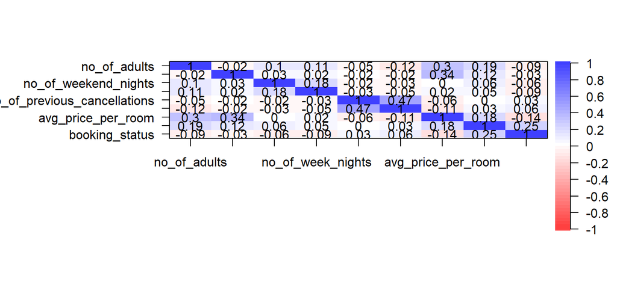

```r
library(psych)
cor.plot(cor(cor))
```

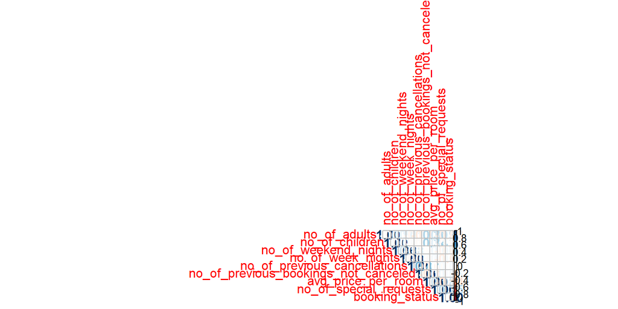

```r
#install.packages("corrplot")
library("corrplot")
corrplot(cor(cor), method="number", type="upper")
```

În matricea de corelație putem observa că nu există legături puternice negative sau pozitive între variabilele noastre, cea mai mai valoare fiind 0.47. Între variabilele no_of_previous_cancellations și no_of_previous_bookings_not_canceled este o legătură directă, ceea ce înseamnă că dacă numărul anulărilor anterioare crește, va crește și numărul rezervărilor neanulate.

### Statistici descriptive

```r
describe(summary)
```

```
                                     vars     n    mean    sd  median trimmed
no_of_adults                            1 36275    1.84  0.52    2.00    1.86
no_of_children                          2 36275    0.11  0.40    0.00    0.00
no_of_weekend_nights                    3 36275    0.81  0.87    1.00    0.74
no_of_week_nights                       4 36275    2.20  1.41    2.00    2.09
required_car_parking_space              5 36275    0.03  0.17    0.00    0.00
lead_time                               6 36275   85.23 85.93   57.00   71.42
arrival_year                            7 36275 2017.82  0.38 2018.00 2017.90
arrival_month                           8 36275    7.42  3.07    8.00    7.55
arrival_date                            9 36275   15.60  8.74   16.00   15.56
repeated_guest                         10 36275    0.03  0.16    0.00    0.00
no_of_previous_cancellations           11 36275    0.02  0.37    0.00    0.00
no_of_previous_bookings_not_canceled   12 36275    0.15  1.75    0.00    0.00
avg_price_per_room                     13 36275  103.42 35.09   99.45  101.32
no_of_special_requests                 14 36275    0.62  0.79    0.00    0.50
booking_status                         15 36275    0.67  0.47    1.00    0.72
                                       mad  min  max range  skew kurtosis   se
no_of_adults                          0.00    0    4     4 -0.33     0.81 0.00
no_of_children                        0.00    0   10    10  4.71    36.97 0.00
no_of_weekend_nights                  1.48    0    7     7  0.74     0.30 0.00
no_of_week_nights                     1.48    0   17    17  1.60     7.80 0.01
required_car_parking_space            0.00    0    1     1  5.41    27.30 0.00
lead_time                            69.68    0  443   443  1.29     1.18 0.45
arrival_year                          0.00 2017 2018     1 -1.67     0.79 0.00
arrival_month                         2.97    1   12    11 -0.35    -0.93 0.02
arrival_date                         11.86    1   31    30  0.03    -1.16 0.05
repeated_guest                        0.00    0    1     1  6.00    34.03 0.00
no_of_previous_cancellations          0.00    0   13    13 25.20   732.59 0.00
no_of_previous_bookings_not_canceled  0.00    0   58    58 19.25   457.29 0.01
avg_price_per_room                   30.02    0  540   540  0.67     3.15 0.18
no_of_special_requests                0.00    0    5     5  1.14     0.88 0.00
booking_status                        0.00    0    1     1 -0.73    -1.46 0.00
```

```r
summary(summary)
```

```
  no_of_adults   no_of_children    no_of_weekend_nights no_of_week_nights
 Min.   :0.000   Min.   : 0.0000   Min.   :0.0000       Min.   : 0.000
 1st Qu.:2.000   1st Qu.: 0.0000   1st Qu.:0.0000       1st Qu.: 1.000
 Median :2.000   Median : 0.0000   Median :1.0000       Median : 2.000
 Mean   :1.845   Mean   : 0.1053   Mean   :0.8107       Mean   : 2.204
 3rd Qu.:2.000   3rd Qu.: 0.0000   3rd Qu.:2.0000       3rd Qu.: 3.000
 Max.   :4.000   Max.   :10.0000   Max.   :7.0000       Max.   :17.000
 required_car_parking_space   lead_time       arrival_year  arrival_month
 Min.   :0.00000            Min.   :  0.00   Min.   :2017   Min.   : 1.000
 1st Qu.:0.00000            1st Qu.: 17.00   1st Qu.:2018   1st Qu.: 5.000
 Median :0.00000            Median : 57.00   Median :2018   Median : 8.000
 Mean   :0.03099            Mean   : 85.23   Mean   :2018   Mean   : 7.424
 3rd Qu.:0.00000            3rd Qu.:126.00   3rd Qu.:2018   3rd Qu.:10.000
 Max.   :1.00000            Max.   :443.00   Max.   :2018   Max.   :12.000
  arrival_date  repeated_guest    no_of_previous_cancellations
 Min.   : 1.0   Min.   :0.00000   Min.   : 0.00000
 1st Qu.: 8.0   1st Qu.:0.00000   1st Qu.: 0.00000
 Median :16.0   Median :0.00000   Median : 0.00000
 Mean   :15.6   Mean   :0.02564   Mean   : 0.02335
 3rd Qu.:23.0   3rd Qu.:0.00000   3rd Qu.: 0.00000
 Max.   :31.0   Max.   :1.00000   Max.   :13.00000
 no_of_previous_bookings_not_canceled avg_price_per_room no_of_special_requests
 Min.   : 0.0000                      Min.   :  0.00     Min.   :0.0000
 1st Qu.: 0.0000                      1st Qu.: 80.30     1st Qu.:0.0000
 Median : 0.0000                      Median : 99.45     Median :0.0000
 Mean   : 0.1534                      Mean   :103.42     Mean   :0.6197
 3rd Qu.: 0.0000                      3rd Qu.:120.00     3rd Qu.:1.0000
 Max.   :58.0000                      Max.   :540.00     Max.   :5.0000
 booking_status
 Min.   :0.0000
 1st Qu.:0.0000
 Median :1.0000
 Mean   :0.6724
 3rd Qu.:1.0000
 Max.   :1.0000
```

### Distribuția variabilelor continue

```r
#install.packages("ggplot2")
#install.packages("psych")
library("ggplot2")
library("psych")
```

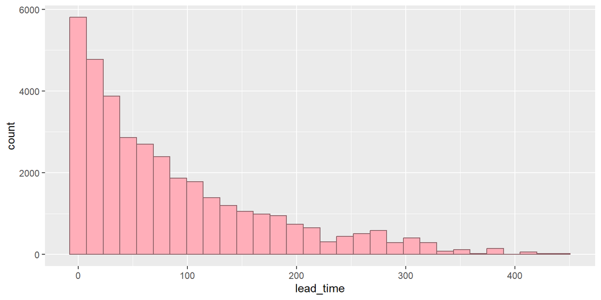

```r
g1 <- ggplot(datei, aes(lead_time))+
  geom_histogram(fill="lightpink1",
                 col="lightpink4")
g1
```

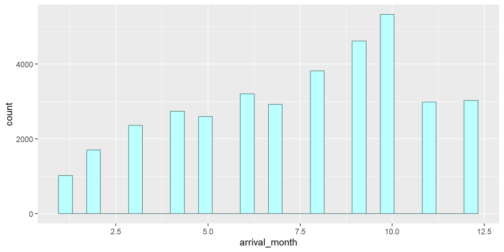

```r
g2 <- ggplot(datei, aes(arrival_month))+
  geom_histogram(fill="paleturquoise1",
                 col="paleturquoise4")
g2
```

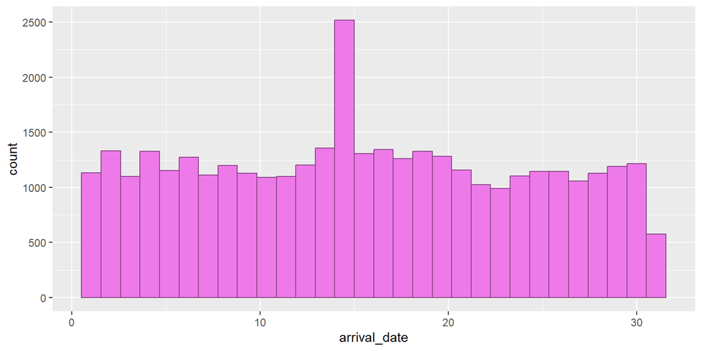

```r
g3 <- ggplot(datei, aes(arrival_date))+
  geom_histogram(fill="orchid2",
                 col="orchid4")
g3
```

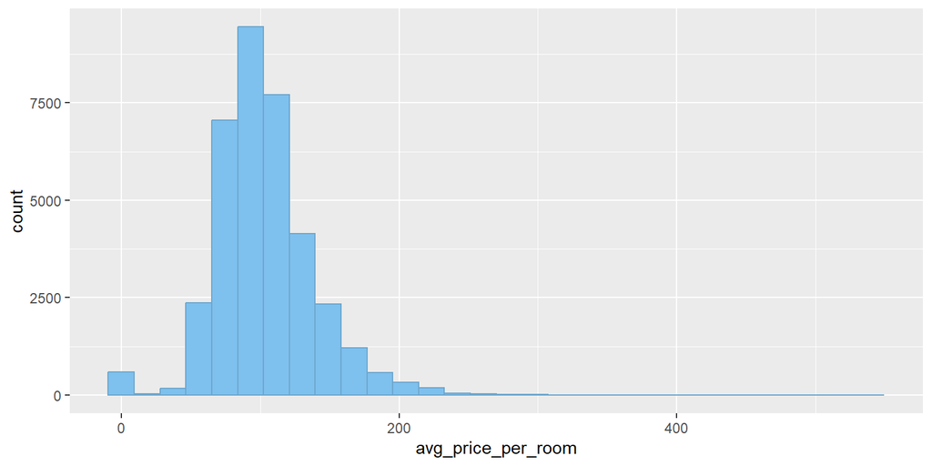

```r
g4 <- ggplot(datei, aes(avg_price_per_room))+
  geom_histogram(fill="skyblue2",
                 col="skyblue3")
g4
```

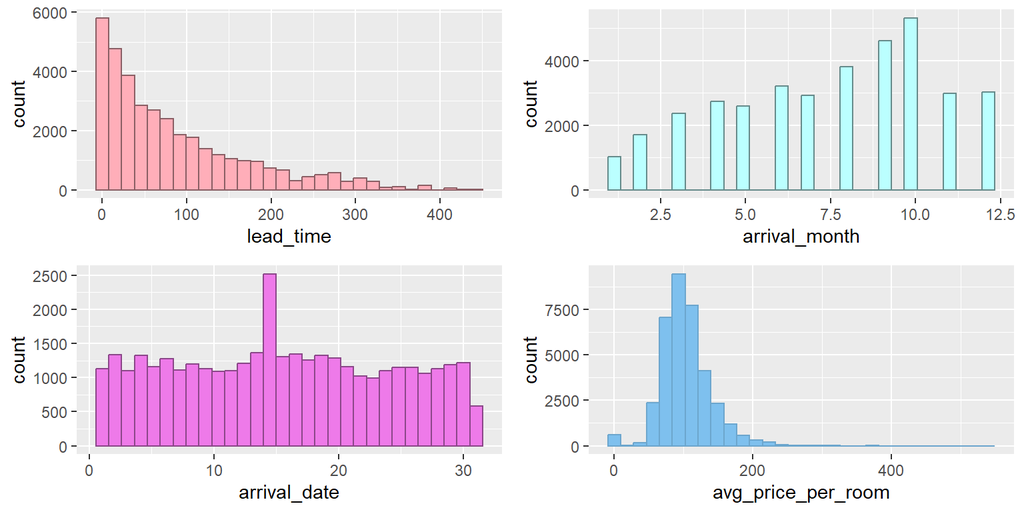

```r
library(gridExtra)
gt<-grid.arrange(g1,g2,g3,g4, ncol=2)
```

În cazul timpului de așteptare, majoritatea clienților fac rezervare cu puțin timp înainte de data dorită. Sezonul preferat al clienților este toamna, fiind înregistrate cele mai multe rezervări. În privința zilei, se observă o preferință pentru jumătatea lunii ca valoare extremă, ziua 15, în care s-au înregistrat aproximativ 2500 de rezevări. Media prețului se situează în intervalul 50-150 euro, având o distribuție asimetrică la dreapta.

**Boxplot**

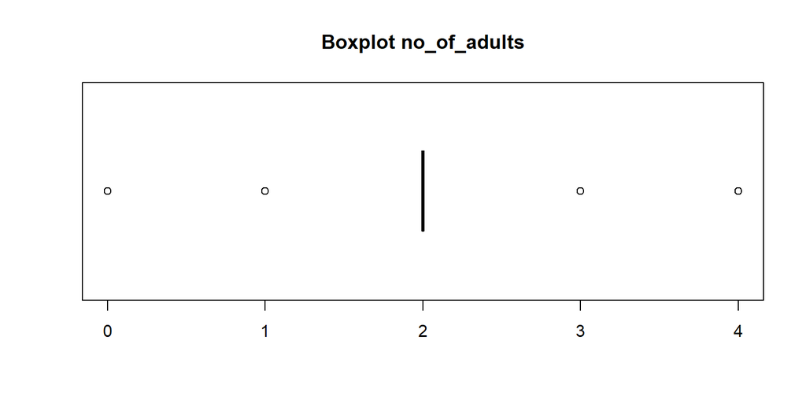

```r
boxplot(date$no_of_adults, main="Boxplot no_of_adults", horizontal =TRUE, col= "pink")
```

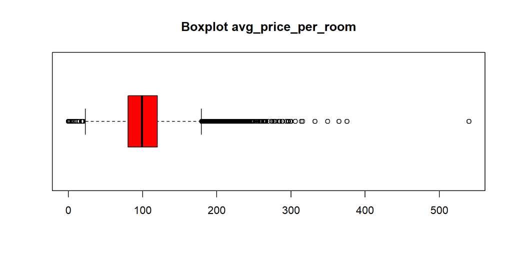

```r
boxplot(date$avg_price_per_room, main="Boxplot avg_price_per_room", horizontal =TRUE, col= "red")
```

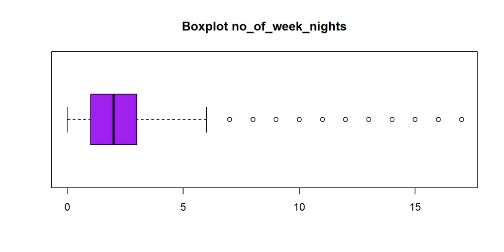

```r
boxplot(date$no_of_week_nights, main="Boxplot no_of_week_nights", horizontal =TRUE, col="purple")
```

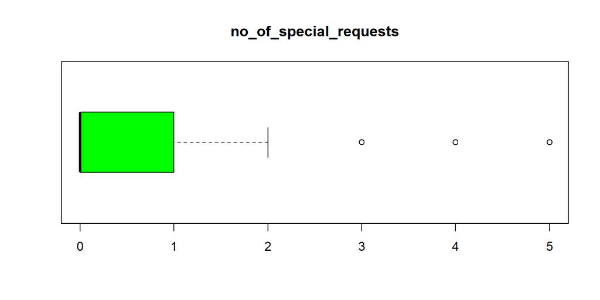

```r
boxplot(date$no_of_special_requests, main="no_of_special_requests", horizontal =TRUE, col="green")
```

Analizând boxplot-ul pentru prețul mediu al unei camere, putem spune că există foarte multe valori extreme, după cum am văzut și mai sus, media fiind de 103 euro pe cameră.

**Reprezentări grafice**

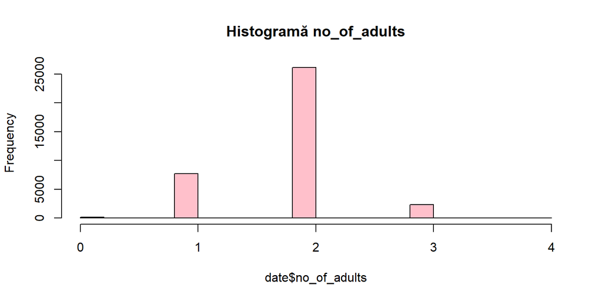

```r
hist(date$no_of_adults, main="Histogramă no_of_adults",col= "pink")
```

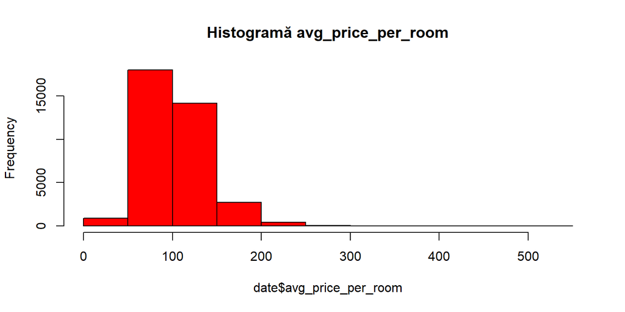

```r
hist(date$avg_price_per_room, main="Histogramă avg_price_per_room", col= "red")
```

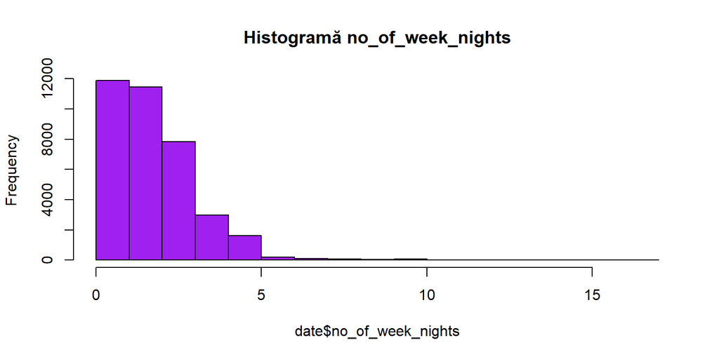

```r
hist(date$no_of_week_nights, main="Histogramă no_of_week_nights", col="purple")
```

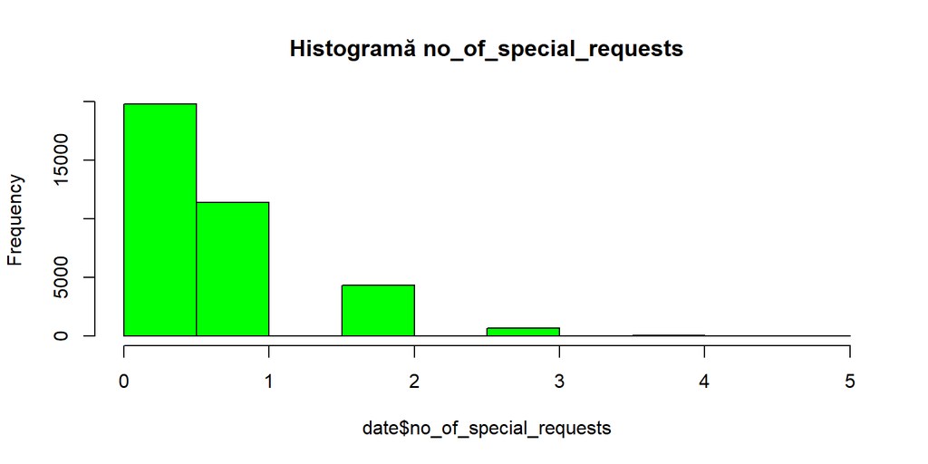

```r
hist(date$no_of_special_requests, main="Histogramă no_of_special_requests", col="green")
```

În histograme este reprezentată frecvența variabilelor no_of_adults, avg_price_per_room, no_of_week_nights, no_of_special_requests.

**Reprezentare dependentă**

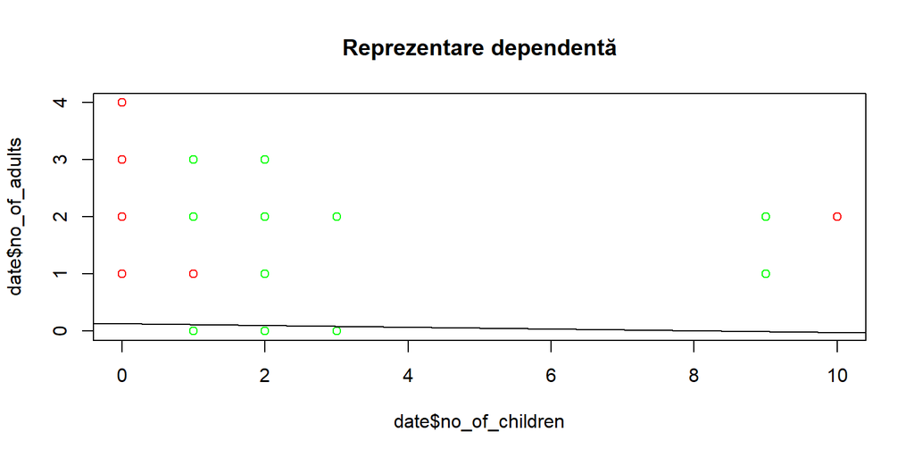

```r
plot(date$no_of_children,date$no_of_adults,col=c("red","green"),main="Reprezentare dependentă")
abline(lm(date$no_of_children~date$no_of_adults))
```

În graficul de mai sus am dorit să surprindem dependența dintre numărul adulților și numărul copiilor pentru a observa câți adulți vin însoțiți de copii. Nu există o dependență puternică între aceste variabile, concluzionând că familiile sunt formate, în general, doar din adulți, aspect motivat de intensitatea slabă a legăturii.

**Ggplot**

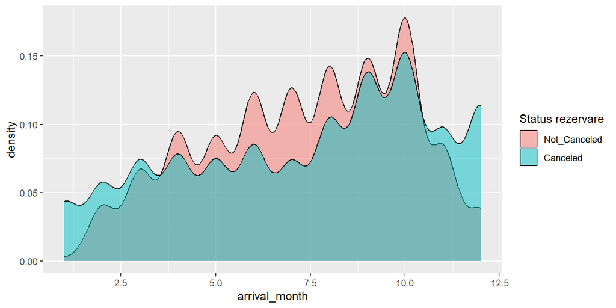

```r
library(ggplot2)
ggplot(datei, aes(x = arrival_month, fill = booking_status)) +
  geom_density(alpha=0.5) +
  scale_fill_discrete(name = "Status rezervare", labels = c("Not_Canceled", "Canceled"))
```

**Densitate lead_time si booking_status**

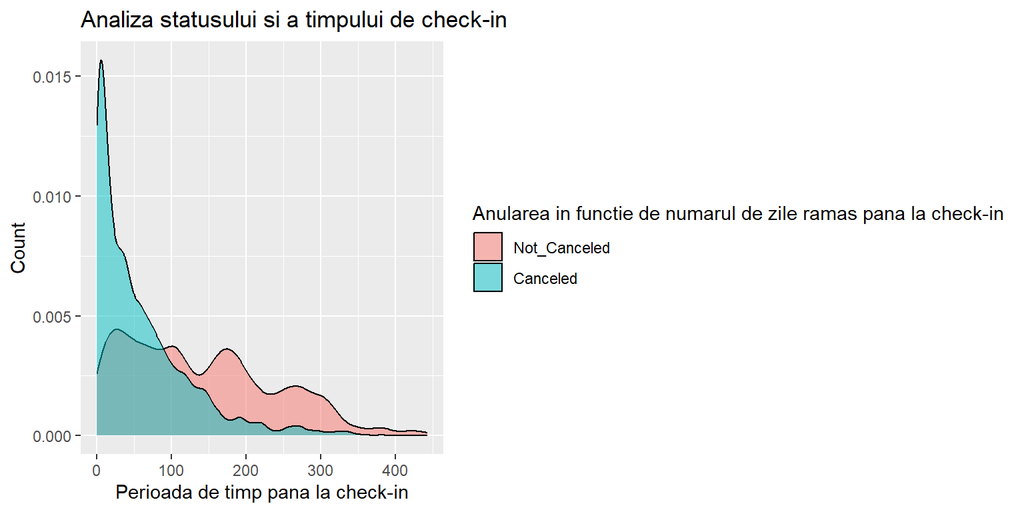

```r
ggplot(datei, aes(x = lead_time, fill = booking_status)) +
  geom_density(alpha=0.5) +
  xlab("Perioada de timp pana la check-in") +
  ylab("Count") +
  ggtitle("Analiza statusului si a timpului de check-in") +
  scale_fill_discrete(name = "Anularea in functie de numarul de zile ramas pana la check-in", labels = c("Not_Canceled", "Canceled"))
```

```r
datem<-date1[,c(15,1,2,3,4,6,11,12,13,14)]
```

## Regresie binomială

Am inițiat o analiză care include variabilele booking_status (variabilă factorizată, binară - care ia valoarea 1 dacă rezervarea nu a fost anulată și 0 dacă rezervarea a fost anulată), lead_time și no_of_previous_cancellations pentru a evidenția influența ultimelor două variabile asupra deciziei clienților de a anula sau nu rezervarea.

**Transformare variabilă dependentă în variabilă factor**

```r
datem$booking_status.f<-factor(datem$booking_status)
library(caTools)
set.seed(88)
```

În faza inițială, vom separa setul de date în 75% set de antrenare și 25% set de testare.

```r
split=sample.split(datem$booking_status, SplitRatio=0.75)
head(split,10)
```

```
 [1]  TRUE  TRUE FALSE FALSE FALSE  TRUE  TRUE  TRUE FALSE FALSE
```

Set de antrenare

```r
setantrenare<-subset(datem, split==TRUE)
s<-data.frame(setantrenare)
```

Standardizare set de antrenare

```r
setantrenare_std<-scale(s[,-11])
nou<-data.frame(setantrenare_std,setantrenare$booking_status.f)
head(nou, 10)
```

```
   booking_status no_of_adults no_of_children no_of_weekend_nights
1        0.698068    0.3008834     -0.2588758            0.2186892
2        0.698068    0.3008834     -0.2588758            1.3706073
6       -1.432473    0.3008834     -0.2588758           -0.9332290
7        0.698068    0.3008834     -0.2588758            0.2186892
8        0.698068    0.3008834     -0.2588758            0.2186892
11       0.698068   -1.6247422     -0.2588758            0.2186892
13      -1.432473    0.3008834     -0.2588758            1.3706073
14      -1.432473   -1.6247422     -0.2588758            1.3706073
15       0.698068    0.3008834     -0.2588758           -0.9332290
16      -1.432473    0.3008834     -0.2588758           -0.9332290
   no_of_week_nights   lead_time no_of_previous_cancellations
1         -0.1417533  1.61051130                  -0.06500336
2          0.5687368 -0.93285233                  -0.06500336
6         -0.1417533  3.02736228                  -0.06500336
```

[output cut: 29 more lines]

Set de testare

```r
settestare<-subset(datem, split==FALSE)
```

**Plot**

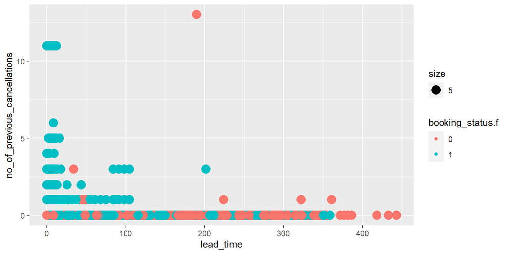

```r
plot<-ggplot(data=datem, aes(x=lead_time, y=no_of_previous_cancellations, col=booking_status.f))
plot<-plot+geom_point(aes(size=5))
plot
```

#### Model1

```r
model<-glm(nou$setantrenare.booking_status.f~lead_time+no_of_previous_cancellations, data=nou, family=binomial)
```

```r
summary(model)
```

```
Call:
glm(formula = nou$setantrenare.booking_status.f ~ lead_time +
    no_of_previous_cancellations, family = binomial, data = nou)

Deviance Residuals:
    Min       1Q   Median       3Q      Max
-2.0613  -0.9097   0.5845   0.7555   2.3570

Coefficients:
                             Estimate Std. Error z value Pr(>|z|)
(Intercept)                   0.80503    0.01450  55.515  < 2e-16 ***
lead_time                    -1.00627    0.01581 -63.630  < 2e-16 ***
no_of_previous_cancellations  0.07433    0.02714   2.738  0.00617 **
---
Signif. codes:  0 '***' 0.001 '**' 0.01 '*' 0.05 '.' 0.1 ' ' 1

(Dispersion parameter for binomial family taken to be 1)

    Null deviance: 34416  on 27205  degrees of freedom
Residual deviance: 29160  on 27203  degrees of freedom
AIC: 29166

Number of Fisher Scoring iterations: 5
```

```r
exp(coef(model))
```

```
                 (Intercept)                    lead_time
                   2.2367539                    0.3655813
no_of_previous_cancellations
                   1.0771573
```

$$2.2367539*bookingstatus=0.3655813*leadtime+1.0771573*no of previous cancellations$$

**Factorizare categorii**

```r
contrasts(datem$booking_status.f)
```

```
  1
0 0
1 1
```

Valoarea 0 a fost asignată rezervărilor anulate, iar valoarea 1 celor neanulate.

**Probabilități**

```r
prob<-predict(model, nou, type="response")
prob1<-predict(model, settestare, type="response")
head(prob)
```

```
         1          2          6          7          8         11
0.30567678 0.85054631 0.09568303 0.80218219 0.69579647 0.85782285
```

Sunt previzionate probabilitățile ca rezervările să fie anulate sau nu. Pentru prima observație, 1, observăm o probabilitate de 31% de a nu fi anulată.

**Predicție set de antrenare**

```r
pred<-rep("0", dim(nou)[1])
pred[prob>.5]="1"
```

**Matricea de confuzie**

```r
table(pred,nou$setantrenare.booking_status.f)
```

```
pred     0     1
   0  3815  1482
   1  5099 16810
```

**Acuratețea**

```r
(3815+16810)/(3815+16810+1482+5099)
```

```
[1] 0.7581048
```

Acuratețea clasificării se determină ca raportul dintre suma elementelor de pe diagonala principală și totalul elementelor: 75.81% din elementele setului de antrenare au fost corect previzionate.

**Predicția modelului**

```r
predictie=predict(model, newdata=data.frame(lead_time=c(34,35), no_of_previous_cancellations=c(50,55)), type="response")
predictie[1]<=0.5
```

```
   1
TRUE
```

```r
predictie[2]<=0.5
```

```
   2
TRUE
```

**Predicție set de testare**

```r
pred1<-rep("0",dim(settestare)[1])
pred1[prob1>.5]="1"
table(pred1, settestare$booking_status.f)
```

```
pred1    0    1
    0 2956 5775
    1   15  323
```

**Acuratețea**

```r
(2956+323)/(2956+323+5775+15)
```

```
[1] 0.3615614
```

**Rata de acuratețe a setului de testare**

```r
mean(pred1==settestare$booking_status.f)
```

```
[1] 0.3615614
```

Rata de acuratețe a setului de testare este 36.16%, deci modelul este slab, putând fi distinse în această proporție rezervările neanulate.

**Curba ROC**

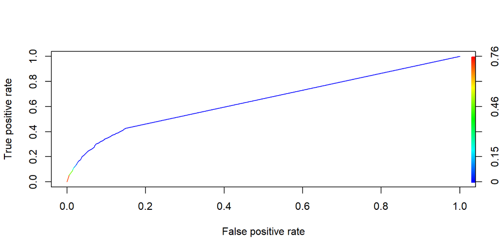

```r
library(ROCR)
p<-predict(model, newdata=settestare, type="response")
pr<-prediction(p, settestare$booking_status.f)
prf<-performance(pr, measure="tpr", x.measure="fpr")
plot(prf, colorize=TRUE)
```

```r
perf<-performance(pr, "auc")
perf<-perf@y.values[[1]]
perf
```

```
[1] 0.6482402
```

Aria de sub curba ROC este 0.6482402. Aceasta aparține intervalului [0,6-0,7], așadar clasificarea este una slabă. Modelul poate distinge în proporție de 64.82% rezervările care pot fi anulate sau nu.

## KNN clasificare - metoda celor mai apropiați vecini

În problemele de învățare automată, algoritmul K-nearest neighbors este o metodă utilizată atât pentru clasificare cât și pentru regresie. Este un algoritm de învățare supervizat care oferă o perspectivă asupra naturii datelor, acesta fiind sensibil la structura locală a datelor. Variabila dependentă Status are 2 clase - 0 pentru rezervări anulate, 1 pentru rezervări neanulate.

```r
library(class)
library(e1071)
date_1<-datem[,-11]
colnames(date_1)[1]<- "Status"
date_1$Statusf<-as.factor(date_1$`Status`)
set.seed(101)
```

Ca primă etapă, am împărțit setul de date în set de antrenare 70% și set de testare 30%.

Eșantioane

```r
ind<-sample(2, nrow(date_1), replace=TRUE, prob=c(0.70,0.30))
```

Setul de antrenare

```r
antrenare<-date_1[ind==1,]
antrenare_std<-scale(antrenare[, c(-1,-11)])
antstd<-data.frame(antrenare$Statusf,antrenare_std)
dim(antstd)[1]
```

```
[1] 25209
```

```r
head(antstd)
```

```
  antrenare.Statusf no_of_adults no_of_children no_of_weekend_nights
1                 1    0.3009287     -0.2625036            0.2156379
2                 1    0.3009287     -0.2625036            1.3590996
4                 0    0.3009287     -0.2625036           -0.9278237
5                 0    0.3009287     -0.2625036            0.2156379
6                 0    0.3009287     -0.2625036           -0.9278237
7                 1    0.3009287     -0.2625036            0.2156379
  no_of_week_nights  lead_time no_of_previous_cancellations
1        -0.1504878  1.6156757                  -0.06376458
2         0.5537347 -0.9345009                  -0.06376458
4        -0.1504878  1.4642954                  -0.06376458
5        -0.8547102 -0.4337813                  -0.06376458
6        -0.1504878  3.0363220                  -0.06376458
7         0.5537347 -0.5968063                  -0.06376458
  no_of_previous_bookings_not_canceled avg_price_per_room
1                          -0.08641924        -1.09833722
2                          -0.08641924         0.09420587
4                          -0.08641924        -0.09692148
5                          -0.08641924        -0.25428681
6                          -0.08641924         0.33225669
7                          -0.08641924         0.11909820
  no_of_special_requests
1             -0.7893524
2              0.4879302
4             -0.7893524
5             -0.7893524
6              0.4879302
7              0.4879302
```

Setul de testare

```r
testare<-date_1[ind==2,]
dim(testare)[1]
```

```
[1] 11066
```

În mod implicit, nivelurile variabilei dependente din acest set de date sunt “0”, “1”. Când vom face predicția, aceste niveluri vor fi folosite ca nume de variabile pentru predicție, astfel încât le vom transforma în nume de variabile valide.

```r
levels(antstd$antrenare.Statusf) <-
make.names(levels(factor(antstd$antrenare.Statusf)))
```

```r
levels(testare$Statusf) <-
make.names(levels(factor(testare$Statusf)))
```

Vom folosi validarea încrucişată cu funcţia trainControl. “numbers” denotă 10 validări încrucişate şi “repeats” faptul că repetăm de 3 ori cele 10 validări încrucişate. Cross-validation =validarea incrucisata (repetata de 10 ori, de exemplu), implica aleator impartirea setului de antrenare in 10 grupe de dimensiune egala. De exemplu, 90% din date sunt utilizate pentru a instrui modelul, iar restul de 10% pentru a il valida. Rata de clasificare este apoi calculata pe datele de validare 10%. Aceasta operatie de repeta de 10 ori. Diferite grupuri de observații sunt tratate ca un set de validare în fiecare din cele 10 repetări. Aceasta conduce la 10 estimări ale erorii de validare, care sunt calculate ca o medie.

-Functia twoClassSummary calculează senzitivitatea, specificitatea și aria de sub curba ROC. -classProbs=TRUE calculează probabilitatea de a aparține claselor 0, 1. -repeatedcv=validare încrucișată (cross validation) repetată -Numărul de reglări ale algoritmului este dat de variabila “tunel”.

Folosind funcția trainControl() din biblioteca “caret” vom rula KNN. Statusf este variabila dependentă. Setarea parametrului preProcess la centru și scală ne spune că standardizăm variabilele independente: - center: scăderea mediei din valori; - scale: împărțim valorile cu abaterea standard. trControl se aplică lui “x”, care a fost obținut prin intermediul funcţiei trainControl() și tunelength este întotdeauna un întreg, care este folosit pentru a regla algoritmul.

```r
library(caret)
repeats = 3
numbers = 10
set.seed(1234)
x = trainControl(method = "repeatedcv", number = numbers,repeats =
repeats, classProbs = TRUE, summaryFunction = twoClassSummary)
tunel = 10
modelknn <- train(antrenare.Statusf~. , data = antstd, method ="knn",
preProcess = c("center","scale"), trControl = x,metric="ROC",
tuneLength = tunel)
modelknn
```

```
k-Nearest Neighbors

25209 samples
    9 predictor
    2 classes: 'X0', 'X1'

Pre-processing: centered (9), scaled (9)
Resampling: Cross-Validated (10 fold, repeated 3 times)
Summary of sample sizes: 22688, 22688, 22688, 22688, 22688, 22688, ...
Resampling results across tuning parameters:

  k   ROC        Sens       Spec
   5  0.8719721  0.6849879  0.9044188
   7  0.8750313  0.6759887  0.9089618
   9  0.8766178  0.6679177  0.9128361
  11  0.8768598  0.6572639  0.9144292
  13  0.8755323  0.6468927  0.9167893
  15  0.8742639  0.6424536  0.9170842
  17  0.8732841  0.6389427  0.9169664
  19  0.8721772  0.6343826  0.9161403
  21  0.8707719  0.6318805  0.9152158
  23  0.8693509  0.6290960  0.9135048

ROC was used to select the optimal model using the largest value.
The final value used for the model was k = 11.
```

- k reprezintă numărul celor mai apropiați vecini ai unei observații;
- ROC=aria de sub curba ROC;
- Sens=senzitivitatea;
- Spec=specificitatea.

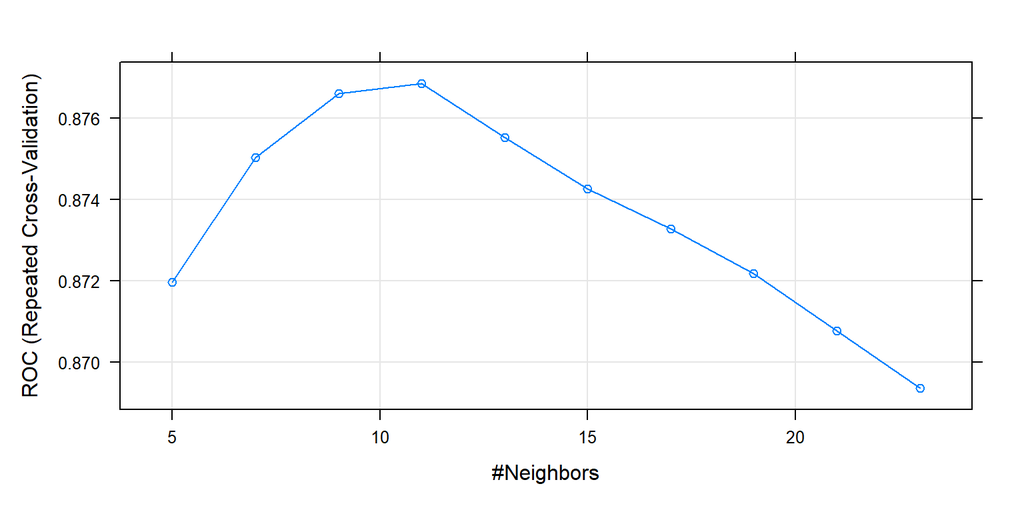

```r
plot(modelknn)
```

În cele din urmă, pentru a face predicții pe setul nostru de validare, vom folosi funcția de predicție în care primul argument este modelul și al doilea argument este dat de noile date pe care ne dorim predicțiile.

```r
valid_pred <- predict(modelknn, testare, type = "prob")
head(valid_pred)
```

```
         X0        X1
1 0.4545455 0.5454545
2 0.4545455 0.5454545
3 0.4545455 0.5454545
4 0.4545455 0.5454545
5 0.7692308 0.2307692
6 0.4545455 0.5454545
```

```r
library(ROCR)
```

Probabilitatea ca prima rezervare să fie anulată este 0.45.

```r
pred_val <-prediction(valid_pred[,2],testare$Statusf)
```

**Calculul ariei de sub curba ROC:**

```r
perf_val <- performance(pred_val,"auc")
perf_val
```

```
A performance instance
  'Area under the ROC curve'
```

**Trasarea curbei ROC:**

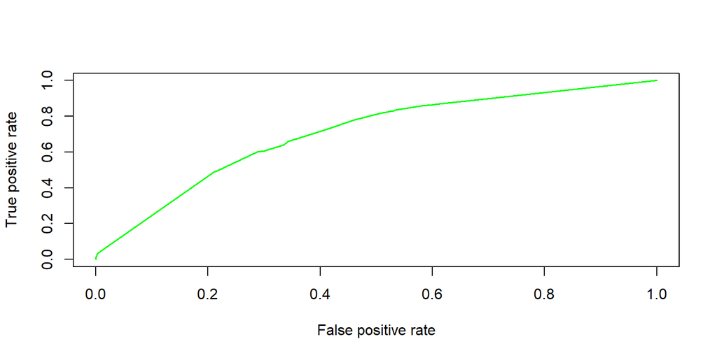

```r
perf_val <- performance(pred_val, "tpr", "fpr")
plot(perf_val, col = "green", lwd = 1.5)
```

```r
auc<-performance(pred_val, measure="auc")
auc<-auc@y.values[[1]]
auc
```

```
[1] 0.7031606
```

Aria de sub curba ROC este 0.703. Aria de sub curba ROC indică șanse de 70.3% de separare a clasei pozitive (status-neanulat) de clasa negativă (status-anulat).

## Random forest

Am aplicat algoritmul Random Forest pentru a realiza predicții pentru variabila booking_status în funcție de celelalte variabile semnificative (care influențează anularea unei rezervari) din setul de date.

Pentru a aplica modelul Randorm Forest avem nevoi de librăria randomForest.

```r
set.seed(40)
#install.packages("randomForest")
library(randomForest)
modelrf = randomForest(setantrenare$booking_status.f~no_of_adults+no_of_children+lead_time+no_of_previous_cancellations+no_of_previous_bookings_not_canceled+avg_price_per_room+no_of_special_requests, data=nou)
modelrf
```

```
Call:
 randomForest(formula = setantrenare$booking_status.f ~ no_of_adults +      no_of_children + lead_time + no_of_previous_cancellations +      no_of_previous_bookings_not_canceled + avg_price_per_room +      no_of_special_requests, data = nou)
               Type of random forest: classification
                     Number of trees: 500
No. of variables tried at each split: 2

        OOB estimate of  error rate: 17.37%
Confusion matrix:
     0     1 class.error
0 5324  3590  0.40273727
1 1137 17155  0.06215832
```

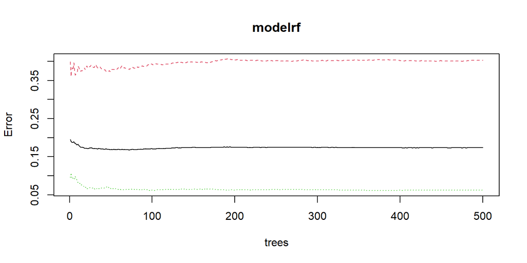

```r
plot(modelrf)
```

```r
importance(modelrf)
```

```
                                     MeanDecreaseGini
no_of_adults                                202.20071
no_of_children                               64.67397
lead_time                                  2634.12816
no_of_previous_cancellations                 14.82847
no_of_previous_bookings_not_canceled         46.06425
avg_price_per_room                         1167.07417
no_of_special_requests                      903.02206
```

MeanDecreaseGini arată cu cât contribuie variabilele în costrucția modelului. În acest model, cele mai importante variabile sunt lead_time, ca și avg_price_per_room, deoarece sunt variabilele cu cele mai mari valori ale acestui indicator. Variabila care pare a nu contribui foarte mult în construcția modelului este no_of_previous_cancellations.

```r
which.min(modelrf$mse)
```

```
integer(0)
```

```r
#sqrt(modelrf$mse[which.min(modelrf$mse)])
```

În graficul următor este evidențiată importanța fiecărei variabile predictive din modelul obținut.

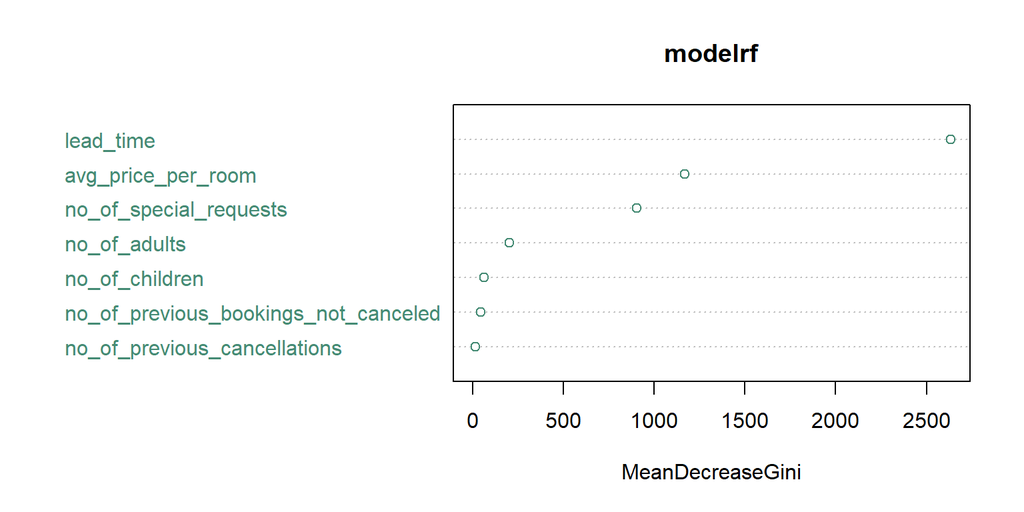

```r
varImpPlot(modelrf,col="aquamarine4")
```

Observăm că variabila lead_time are cea mai mare influență.

Implicit, funcția utilizează 500 de copaci și aleator selectează potențiali candidați predictori la fiecare iterație.

ntreeTry: The number of trees to build. mtryStart: The starting number of predictor variables to consider at each split. stepFactor: The factor to increase by until the out-of-bag estimated error stops improving by a certain amount. improve: The amount that the out-of-bag error needs to improve by to keep increasing the step factor.

```
mtry = 1  OOB error = 2.29%
Searching left ...
mtry = 2    OOB error = 0%
1 11
Searching right ...
```

```
mtry = 0    OOB error = 1.63%
0.2877814 11
```

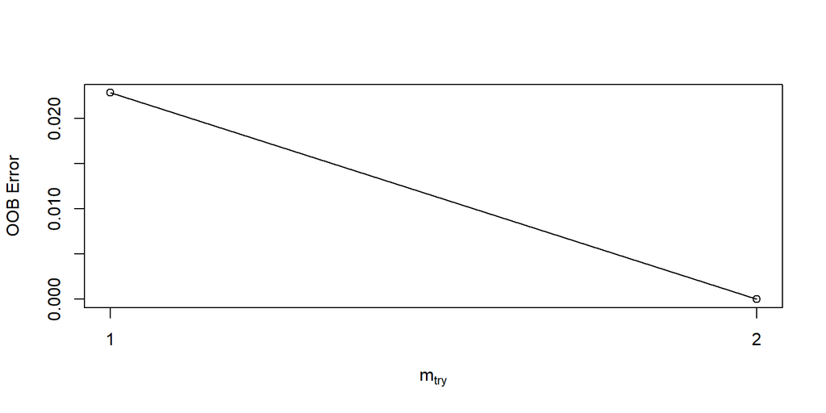

```r
model_tuned <- tuneRF(
               x=nou[,-11],
               y=nou$setantrenare.booking_status.f,
               ntreeTry=500,
               mtryStart=1,
               stepFactor=0.5,
               improve=11,
              )
```

```r
new1 <- data.frame(no_of_adults=3,no_of_children=2,lead_time=31,no_of_previous_cancellations=0, no_of_previous_bookings_not_canceled=2,avg_price_per_room=164,no_of_special_requests=1)
new1
```

```
  no_of_adults no_of_children lead_time no_of_previous_cancellations
1            3              2        31                            0
  no_of_previous_bookings_not_canceled avg_price_per_room
1                                    2                164
  no_of_special_requests
1                      1
```

Se va utiliza modelul pentru a realiza o predicție.

```r
predict(modelrf, newdata=new1)
```

```
1
0
Levels: 0 1
```

Abordarea utilizată nu a condus către model valid.

**Altă abordare pentru predicție:**

```r
prediction_for_table = predict(modelrf,settestare)
matrice_test=table(observed=settestare[,11],predicted=prediction_for_table)
round(mean(prediction_for_table==settestare$booking_status.f),4)*10
```

```
[1] 3.832
```

```r
round(mean(prediction_for_table!=settestare$booking_status.f),4)*100
```

```
[1] 61.68
```

```r
library(e1071)
round(classAgreement(matrice_test)$kappa,4)*100
```

```
[1] 5.41
```

```r
predictie_modelrf = predict(modelrf, newdata=settestare)
head(predictie_modelrf,10)
```

```
 3  4  5  9 10 12 17 28 29 31
 0  0  0  0  1  0  1  0  0  0
Levels: 0 1
```

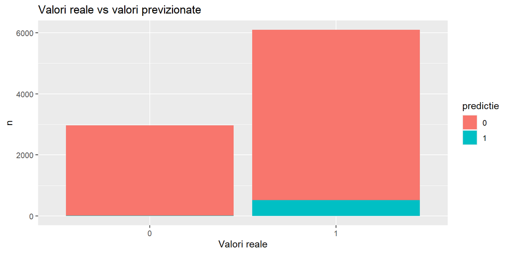

```r
library(ggplot2)
grafic=data.frame(predictie_modelrf,settestare$booking_status.f)
colnames(grafic)=c("predictie","val_reale")
grafic %>% group_by(predictie,val_reale) %>% dplyr::summarise(n=n()) %>%
  ggplot()+
  geom_col(aes(x=val_reale,y=n,fill=predictie))+
    labs(x="Valori reale", title="Valori reale vs valori previzionate")
```

Modelul previzionat nu respectă distribuția valorilor reale. În modelul real există mai multe rezervări neanulate. Modelul nu distinge între clasa pozitivă și cea negativă.

## Concluzia

Aplicând modelul regresiei binomiale pentru variabilele booking_status, lead_time și no_of_previous_cancellations, am observat că modelul este slab, existând o clasificare slabă, 64.82% șanse ca modelul să poată distinge rezervările care vor fi anulate sau nu. Modelul poate fi îmbunătățit prin adăugarea altor variabile care să aibă o corelație mult mai puternică cu variabila dependentă. Am observat, însă, că dacă rezervarea a fost înregistrată cu puțin timp înainte de data check-in-ului clienții au onorat rezervările, acesta fiind cel mai semnificativ coeficient al modelului. După utilizarea modelului KNN (metoda celor mai apropiați vecini) am obținut o valoare de 70.3% șanse de separare a clasei pozitive (status-neanulat) de clasa negativă (status-anulat), observându-se o îmbunătățire față de modelul regresiei. În acest model variabila booking_status=Status este dependentă, analizată împreună cu toate celelalte variabile independente numerice (no_of_adults, no_of_children, no_of_weekend_nights, no_of_week_nights, lead_time, no_of_previous_cancellations, no_of_previous_bookings_not_canceled, avg_price_per_room, no_of_special_requests). Modelul poate, de asemenea, să fie îmbunătățit până la o valoare de 100% șanse de separare. Modelul Random Forest este cel mai slab, nu face distincție între rezervări, predicția nefiind relevantă.

În urma aplicării celor 3 modele asupra setului nostru de date, putem afirma că modelul KNN realizează cea mai bună predicție asupra rezervărilor anulate sau neanulate în funcție de celelalte variabile luate în calcul.

Soluția noastră în urma analizei efectuate este de a crea un model în care variabila dependentă e corelată puternic cu variabilele incluse în analiză. Totodată, putem introduce în setul de date noi variabile observate în acest context (Se poate crea un chestionar pentru a înțelege care sunt motivele anulărilor). O nouă variabilă posibilă ar putea fi avansul (% din suma totală) întrucât clienții pot fi determinați să nu mai anuleze o rezervare dacă valoarea avansului este mare.

Sursa datelor: [Link](https://www.kaggle.com/datasets/ahsan81/hotel-reservations-classification-dataset)